# HW12: Dates

Andrea Winingar

30 July 2020

Load packages.

```r
library(lubridate)
```

Source my_functions.R

```r
my_functions <- source(here('Scripts', 'my_functions.R'))
```

### Part 1: Play Date

Insert chunk from homework of pioneer women scientists.

```r
birth_date <- "September 23, 1999"

# Elizabeth Garret Anderson was the first female physician
anderson <- "9 June 1836"

# Mary Anning discovered the first complete Plesiosaur fossil,
# and other important Jurassic fossils
anning <-  "1799/05/21"

# Alice Augusta Ball was a chemist who developed the
# first injectable treatment for leprosy.
ball <- "July 24, 1892"

# Sylvia Earle was the first chieft scientist at NOAA
earle <- "August, 30 (1935)"

# Rosalind Franklin used x-ray diffraction to
# discover DNA structure. Watson and Crick claimed credit.
franklin <- "25th of July, 1920"

# Ester Lederberg was the first to discover that viruses
# infect bacteria. Led to discovery of lambda bacteriophage
lederberg <- "December 18, 1922"

# Barbara McClintock discovered transposable elements (jumping genes),
# and developed staining techniques to study chromosomes
mcclintock <- "16061902"

# Let's also remember a dream
mlk_birth <- "1/15/29"
mlk_dream <- "1963 August 28"
```

#### Questions

1. Convert each date to POSIXct format, using lubridate functions, saving each to a unique variable. Print each result.

```r
birth_date_dt <- mdy(birth_date)
print(birth_date_dt)
```

```
[1] "1999-09-23"
```

```r
anderson_dt <- dmy(anderson)
print(anderson_dt)
```

```
[1] "1836-06-09"
```

```r
anning_dt <- ymd(anning)
print(anning_dt)
```

```
[1] "1799-05-21"
```

```r
ball_dt <- mdy(ball)
print(ball_dt)
```

```
[1] "1892-07-24"
```

```r
earle_dt <- mdy(earle)
print(earle_dt)
```

```
[1] "1935-08-30"
```

```r
franklin_dt <- dmy(franklin)
print(franklin_dt)
```

```
[1] "1920-07-25"
```

```r
lederberg_dt <- mdy(lederberg)
print(lederberg_dt)
```

```
[1] "1922-12-18"
```

```r
mcclintock_dt <- ydm(mcclintock)
print(mcclintock_dt)
```

```
[1] "1606-02-19"
```

```r
mlk_birth_dt <- mdy(mlk_birth)
print(mlk_birth_dt)
```

```
[1] "2029-01-15"
```

```r
mlk_dream_dt <- ymd(mlk_dream)
print(mlk_dream_dt)
```

```
[1] "1963-08-28"
```

2. Check yours dates to be sure they are correct. If you spot any errors, correct them now using the proper lubridate function(s).

```r
print(mlk_birth_dt_new)
```

```
[1] "1929-01-15"
```

3. What day of the week were you born on? Show the full day name, not the abbreviated name or the day number.

```r
weekdays(birth_date_dt, abbreviate = FALSE)
```

[output not shown]

4. What day of the week will your birthday be on this year? Use lubridate’s update function. You must figure out how to do it entirely by code for full points (no hard-coding). In other words, you code should work just as well next year or five years in the future, without editing.

```r
update(birth_date_dt, year = 2020) %>%
  weekdays(abbreviate = FALSE)
```

```
[1] "Wednesday"
```

5. What day of the week would your birthday be on in the Year 2525, if Man is still alive? How old would you be? Here you may hard-code 2525. Show the abbreviated day of the week.

```r
update(birth_date_dt, year = 2525) %>%
  weekdays(abbreviate = TRUE)
```

```
[1] "Sun"
```

6. How many days was it between the birth of Dr. Elizabeth Garrett Anderson and Alice Augusta Ball?

```r
print(anderson_ball)
```

```
Time difference of -20499 days
```

7. What is the duration between Martin Luther King Jr.’s birth date and his I Had a Dream speech.

```r
as.duration(king)
```

```
[1] "1092355200s (~34.61 years)"
```

```r
print(rev(difference))
```

```
Time differences in days
      King McClintock  Lederberg   Franklin      Earle       Ball
    -25818    -143756     -28038     -28914     -23400     -39141
    Anning   Anderson   Winingar
    -73173     -59640          0
```

### Part 2: Wrangling and Plotting with Dates

Import data. Remove lakes other than lake mendota

| iceon_year | iceon_month | iceon_day | iceoff_year | iceoff_month | iceoff_day |
| --- | --- | --- | --- | --- | --- |
| NA | NA | NA | 1853 | 4 | 5 |
| 1853 | 12 | 27 | NA | NA | NA |
| 1855 | 12 | 18 | 1856 | 4 | 14 |
| 1856 | 12 | 6 | 1857 | 5 | 6 |
| 1857 | 11 | 25 | 1858 | 3 | 26 |
| 1858 | 12 | 8 | 1859 | 3 | 14 |
| 1859 | 12 | 7 | 1860 | 3 | 26 |
| 1860 | 12 | 14 | 1861 | 4 | 10 |
| 1861 | 12 | 2 | 1862 | 4 | 13 |
| 1862 | 12 | 26 | 1863 | 4 | 9 |

[output cut: 150 more lines]

Use lubridate functions to assemble the ice on year, month, and date into an ice_on date column. Use the same process to assemble the ice off information to make an ice_off date column.

[output not shown]

[output cut: 150 more lines]

Create a new duration column by subtracting ice_on from ice_off. Make a note of the unit of time for duration.

| iceon_year | iceon_month | iceon_day | iceoff_year | iceoff_month | iceoff_day | ice_on | ice_off | duration |
| --- | --- | --- | --- | --- | --- | --- | --- | --- |
| NA | NA | NA | 1853 | 4 | 5 |  | 1853-04-05 | NA |
| 1853 | 12 | 27 | NA | NA | NA | 1853-12-27 |  | NA |
| 1855 | 12 | 18 | 1856 | 4 | 14 | 1855-12-18 | 1856-04-14 | 118 |
| 1856 | 12 | 6 | 1857 | 5 | 6 | 1856-12-06 | 1857-05-06 | 151 |
| 1857 | 11 | 25 | 1858 | 3 | 26 | 1857-11-25 | 1858-03-26 | 121 |
| 1858 | 12 | 8 | 1859 | 3 | 14 | 1858-12-08 | 1859-03-14 | 96 |
| 1859 | 12 | 7 | 1860 | 3 | 26 | 1859-12-07 | 1860-03-26 | 110 |
| 1860 | 12 | 14 | 1861 | 4 | 10 | 1860-12-14 | 1861-04-10 | 117 |
| 1861 | 12 | 2 | 1862 | 4 | 13 | 1861-12-02 | 1862-04-13 | 132 |
| 1862 | 12 | 26 | 1863 | 4 | 9 | 1862-12-26 | 1863-04-09 | 104 |

[output cut: 150 more lines]

make line graph duration vs. ice_off.

[figure not shown]

### Soil Carbon Dioxide

Import data

| DayN[] | Datecode[] | Min[] | Veg[] | Plot[] | Group[] | CorrCO2[] | SoilT[] |
| --- | --- | --- | --- | --- | --- | --- | --- |
| 481 | 1 | 0 | 1 | 6 | 1 | 398.18 | 291.1 |
| 481 | 1 | 15 | 1 | 6 | 1 | 510.06 | 291.1 |
| 481 | 1 | 30 | 1 | 6 | 1 | 499.62 | 291.1 |
| 481 | 1 | 0 | 1 | 18 | 2 | 474.52 | 290.8 |
| 481 | 1 | 15 | 1 | 18 | 2 | 674.17 | 290.8 |
| 481 | 1 | 30 | 1 | 18 | 2 | 763.96 | 290.8 |
| 481 | 1 | 0 | 1 | 14 | 3 | 801.90 | 289.3 |
| 481 | 1 | 15 | 1 | 14 | 3 | 764.36 | 289.3 |
| 481 | 1 | 30 | 1 | 14 | 3 | 830.51 | 289.3 |
| 481 | 1 | 0 | 1 | 10 | 4 | 404.05 | 290.8 |

[output cut: 990 more lines]

Establish POSIXct-compatible variable. Rename columns. Make date column. Create year column. create month column. group by year and month. summarize mean co2 and standard error of mean.

| year | month | mean_co2 | std_err_mean |
| --- | --- | --- | --- |
| 2007 | Apr | 610.3469 | 18.16704 |
| 2007 | May | 878.8084 | 16.55794 |
| 2007 | Jun | 1039.9411 | 25.53794 |
| 2007 | Jul | 970.0604 | 31.19578 |
| 2007 | Aug | 1115.6591 | 53.41010 |
| 2007 | Sep | 1004.7191 | 30.35294 |
| 2007 | Oct | 686.1444 | 14.27253 |
| 2008 | Apr | 640.8884 | 12.27243 |
| 2008 | May | 961.0424 | 32.14498 |
| 2008 | Jun | 1151.2460 | 36.37925 |

[output cut: 26 more lines]

Make a column chart

```r
ggplot(data = soil_summarized) +
  geom_col(mapping = aes(x = month, y = mean_co2)) +
  geom_linerange(x = month, ymin = mean_co2 - std_err_mean, ymax = mean_co2 +  std_err_mean) +
  facet_wrap(~ year)
```

[output not shown]

[output not shown]

Same plot but with points

```r
soil_summarized %>%
  ggplot() +
  geom_point(mapping = aes(x = month, y = mean_co2)) +
  geom_linerange(x = month, ymin = mean_co2 - std_err_mean, ymax = mean_co2 + std_err_mean) +
  facet_wrap(~ year)
```

[output not shown]

[output not shown]

### Mississippi River Discharge

| year | Month | mean_discharge | event |
| --- | --- | --- | --- |
| 1988 | 1 | 189.38710 | Drought |
| 1988 | 2 | 211.20690 | Drought |
| 1988 | 3 | 211.19355 | Drought |
| 1988 | 4 | 266.76667 | Drought |
| 1988 | 5 | 140.06452 | Drought |
| 1988 | 6 | 83.85667 | Drought |
| 1988 | 7 | 73.60000 | Drought |
| 1988 | 8 | 71.63871 | Drought |
| 1988 | 9 | 75.86000 | Drought |
| 1988 | 10 | 76.96452 | Drought |

[output cut: 362 more lines]

Make a second data set

```r
events <- river_event %>%
  filter(year == 1988, 1993, 2011, 2012)
```

[output not shown]

[output not shown]

plot data.

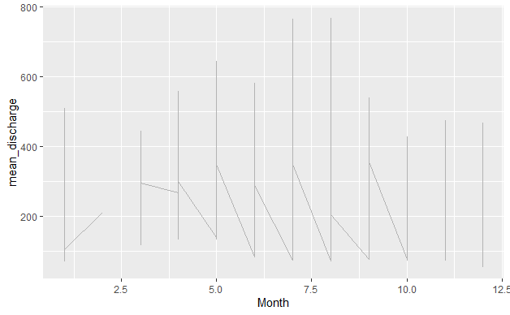